# San Francisco Bay Area Bike-Sharing

## by Ahmed Hamdan

## Investigation Overview

> In this investigation, I wanted to look at the distribution of using bike-share system over 24/7 and the most age group using bike share system. The main focus were on: duration in seconds, member birth year, gender, start day and hour.

## Dataset Overview

> Dataset Overview

The dataset consists of trip and user details for each bike usage in February 2019, covering approximately 175,000 trips. The attributes include:

- Trip Details: Start and end time, start and end station.
- User Details: Gender, birth year, and subscription type.

## Data Cleaning Process

To ensure data quality, the following steps were taken:

- Removed Trips with Missing Data
  - 8,462 trips were excluded due to incomplete records.
- Filtered Out Unusually Long Trips
  - The dataset was limited to trips lasting a maximum of 45 minutes, removing 2,306 trips that exceeded this limit.
  - This threshold was set based on the primary purpose of bike-sharing systems—providing fast, point-to-point urban transportation rather than long-term bike usage.
- Excluded Trips from Users Aged 80+
  - 203 trips were removed, as data from users aged above 80 years were considered potentially inaccurate or unsafe for bike-sharing usage.

## Distribution of Bike Using Duration

> The duration of bike trips in the dataset varies significantly, ranging from as short as 1 minute to a maximum of 45 minutes.

> When plotted on a logarithmic scale, the distribution exhibits a unimodal shape, with a clear peak around 9 minutes. This indicates that most users take short trips, reinforcing the primary function of bike-sharing as **a quick and efficient urban mobility solution**.

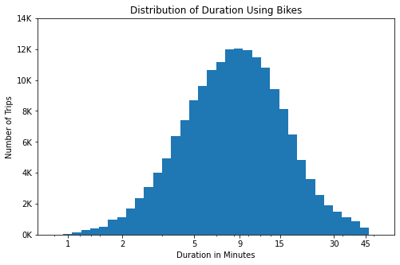

```python
bins = 10 ** np.arange(1.7, np.log10(bike_df['duration_sec'].max())+0.1, 0.05)
plt.figure(figsize=[8,5])
plt.hist(data = bike_df, x = 'duration_sec', bins = bins)
plt.xscale('log')
#adjust x-ticks
plt.xticks([60,120, 300,540, 900, 1800, 2700], ["1", '2','5','9' ,'15','30','45' ])
#adjust y-ticks
yticks = np.arange(0,14000+2000, 2000)
labels = tick_count_covert(yticks)
plt.yticks(yticks,labels)
plt.ylabel('Number of Trips')
plt.xlabel('Duration in Minutes')
plt.title('Distribution of Duration Using Bikes');
```

## Trips and Durations on Weekly Basis

> Bike usage follows a distinct weekly pattern, with the number of trips on weekdays nearly double that of weekends. This suggests that bike-sharing is primarily used for weekday commuting.

> However, while fewer trips occur on weekends, the average trip duration is slightly longer compared to weekdays. This indicates a shift in user behavior, where bikes are likely used for leisure, recreational rides, or casual outings rather than short, point-to-point commuting.

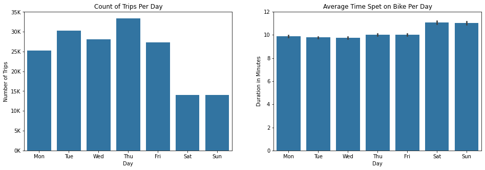

```python
#check the bike_share distribution
color_base= sb.color_palette()[0]
plt.figure(figsize=[16,5])
plt.subplot(1,2,1)
sb.countplot(data= bike_df, x='day', color = color_base)
yticks = np.arange(0, 38000+2000, 5000)
labels = tick_count_covert(yticks)
plt.yticks(yticks,labels)
plt.ylabel('Number of Trips')
plt.xlabel('Day')
plt.title('Count of Trips Per Day');
plt.subplot(1,2,2)
sb.barplot(data = bike_df[bike_df.member_gender.isin(['Male','Female'])], x = 'day',  y ='duration_sec', color= color_base )
ticks = np.arange(0,700+120, 120)
labels = tick_seconds_covert(ticks)
plt.yticks(ticks,labels)
plt.ylabel('Duration in Minutes')
plt.xlabel('Day')
plt.title('Average Time Spet on Bike Per Day');
```

## Trips and Durations on Hourly Basis

> The distribution of trips by hour highlights that the bike-sharing system is primarily used as a commuting method. On weekdays, trip volume peaks at 8 AM and 5 PM, aligning with typical work start and end times. This pattern suggests that many users rely on bike-sharing for traveling to and from work.

> During off-peak hours, trip counts decline, reinforcing the idea that bike-sharing serves as a convenient alternative to public transport for daily commuters rather than a consistently used mode of transport throughout the day.

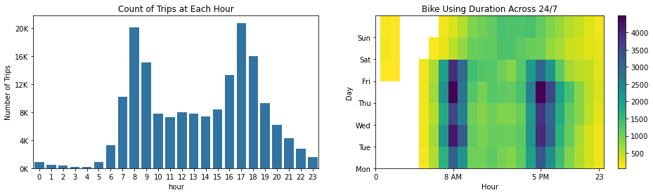

```python
#check the bike using at per start time hour
color_base= sb.color_palette()[0]
plt.figure(figsize=[16,4])
plt.subplot(1,2,1)
sb.countplot(data= bike_df, x='hour', color = color_base)
ticks = np.arange(0,20000+2000, 4000)
labels = tick_count_covert(ticks)
plt.yticks(ticks,labels)
plt.ylabel('Number of Trips')
plt.xlabel('hour')
plt.title('Count of Trips at Each Hour');
plt.subplot(1,2,2)
#Check relation between day and hours for bike usage
#we select cmin = 61 as it the minimum time spent on a trip
bike_df['day_num'] = bike_df['start_time'].apply(lambda time: time.dayofweek)
bin_x=np.arange(0.5,23.4+1,1)
bin_y=np.arange(0,7+1,1)
plt.hist2d(data = bike_df,x= 'hour', y = 'day_num' ,cmin = 61, cmap ='viridis_r', bins=[bin_x, bin_y] );
plt.yticks([0,1,2,3,4,5,6],['Mon','Tue','Wed','Thu','Fri','Sat','Sun'])
plt.xticks([0,8,17,23], [0,'8 AM', '5 PM', 23])
plt.xlabel('Hour')
plt.ylabel('Day')
plt.title('Bike Using Duration Across 24/7')
plt.colorbar();
```

## Weeddays VS. Weekends

> Bike usage patterns differ significantly between weekdays and weekends.
- **Weekdays**: Usage is primarily driven by commuting needs, with clear peaks at 8 AM and 5 PM, corresponding to work start and end times.
- **Weekend**s: The structured commuting pattern disappears, and bike usage becomes more evenly distributed throughout the day, with activity rising from 10 AM and continuing until 6 PM.
- **Late-Night Usage**: Unlike weekdays, bike trips extend past midnight on weekends, indicating increased usage for leisure, social outings, or late-night travel.

This shift suggests that while bike-sharing is a commuter-focused service during the week, it transitions into a recreational and flexible transport option on weekends.

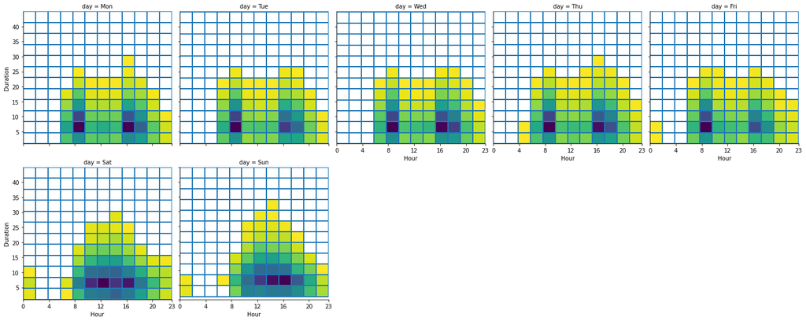

```python
#Bike using duration over the day hours per each day
g = sb.FacetGrid(data = bike_df, col = 'day', col_wrap = 5, size =4)

g.map(plt.hist2d, 'hour', 'duration_sec', cmin=61, cmap ='viridis_r', bins = 12,)
y_ticks = np.arange(0,2700+300, 300)
y_labels = tick_seconds_covert(y_ticks)
plt.yticks(y_ticks,y_labels)
x_ticks=np.arange(0.5,23+1.5,1)
#we select cmin = 61 as it the minimum time spent on a trip
plt.xticks([0,4,8,12,16,20,23], ['0','4','8','12','16', '20', '23'])
g.set_xlabels('Hour')
g.set_ylabels('Duration');
```

## Age and Bike Usage Trends

> The majority of bike-share users fall within the 20 to 40-year-old age group. This segment takes the highest number of trips and exhibits a wide range of trip durations, typically between 5 and 45 minutes, with most trips lasting under 15 minutes.

> As users age, both trip frequency and duration decline, indicating that older individuals are less reliant on bike-sharing. This trend suggests that bike-sharing is more popular among younger, active commuters, while older users may prefer alternative transportation methods.

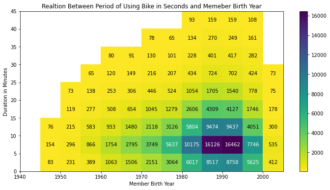

```python
# chech relation between member bithday and duration
plt.figure(figsize=[12,6])
bins_x = np.arange(1940, 2001+5, 5)
bins_y = np.arange(0, 2700+1, 300)

h2d = plt.hist2d(data = bike_df,x= 'member_birth_year', y = 'duration_sec' ,cmin =61, cmap ='viridis_r',bins = [bins_x, bins_y] )
counts = h2d[0]
for i in range(counts.shape[0]):
    for j in range(counts.shape[1]):
        c = counts[i,j]
        if c >= 5000: # increase visibility on darker cells
            plt.text(bins_x[i]+2.5, bins_y[j]+150, int(c),
                     ha = 'center', va = 'center', color = 'white')
        elif c > 0:
            plt.text(bins_x[i]+2.5, bins_y[j]+150, int(c),
                     ha = 'center', va = 'center', color = 'black')
plt.xlabel('Member Birth Year')
ticks= np.arange(0,2700+300,300)
labels= []
for i in ticks:
    labels.append(str(int(i/60)))
#plt.yticks([5,10,15,20,25,30,35,40,45], ['5','10','15','20','25','30','35','40', '45'])
plt.yticks(ticks,labels)
plt.ylabel('Duration in Minutes')
plt.title('Realtion Between Period of Using Bike in Seconds and Memeber Birth Year')
plt.colorbar();
```

## Male vs. Female Bike Usage

- **Trip Volume**: Males take significantly more trips than females, indicating higher overall engagement with the bike-sharing system.
- **Trip Duration**: While females take fewer trips, they spend slightly more time per ride on average compared to males.

This suggests potential differences in **trip purpose** or **riding behavior**, where males may use bikes more frequently for short, point-to-point commutes, while females may take longer, more leisurely rides.

Understanding these patterns can help tailor marketing strategies and service improvements to encourage higher female participation.

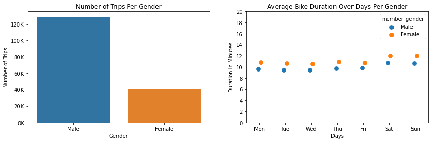

```python
#Check the avergar duration using bikes over days per gender
plt.figure(figsize=[14,4])
plt.subplot(1,2,1)
#check the gender distribution
color_base = sb.color_palette()[0]
sb.countplot(data = bike_df[bike_df.member_gender.isin(['Male','Female'])], x= 'member_gender')
ticks = np.arange(0,120000+2000, 20000)
labels = tick_count_covert(ticks)
plt.yticks(ticks,labels)
plt.ylabel('Number of Trips')
plt.xlabel('Gender')
plt.title('Number of Trips Per Gender');
plt.subplot(1,2,2)
sb.pointplot(data = bike_df[bike_df.member_gender.isin(['Male','Female'])], x = 'day',  y ='duration_sec',
             hue='member_gender', dodge=0.1, linestyles='' );
ticks = np.arange(0,1200+120, 120)
labels = tick_seconds_covert(ticks)
plt.yticks(ticks,labels)
plt.xlabel('Days')
plt.ylabel('Duration in Minutes')
plt.title('Average Bike Duration Over Days Per Gender');
```

## Hourly Bike Usage and Duration by Gender

- Throughout the day, males consistently take more trips than females, but the average trip duration remains relatively close between genders.
- After midnight, the gap in average trip duration widens, with females spending more time per trip than males.

This trend suggests that safety concerns may influence female riders' behavior, making bikes a preferred alternative to walking during late-night hours. Addressing these concerns through well-lit bike stations, safer routes, and targeted safety initiatives could encourage even greater female participation in the bike-sharing system.

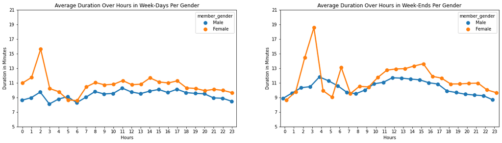

```python
plt.figure(figsize = [20, 5])
plt.subplot(1,2,1)
sb.pointplot(data = week_days[week_days.member_gender.isin(['Male','Female'])], x = 'hour',  y ='duration_sec',
             hue='member_gender', dodge=True, ci = None );
ticks = np.arange(300,1200+120, 120)
labels = tick_seconds_covert(ticks)
plt.yticks(ticks,labels)
plt.xlabel('Hours')
plt.ylabel('Duration in Minutes')
plt.title('Average Duration Over Hours in Week-Days Per Gender');
plt.subplot(1,2,2)
sb.pointplot(data = week_ends[week_ends.member_gender.isin(['Male','Female'])], x = 'hour',  y ='duration_sec',
             hue='member_gender', dodge=0.4 , ci = None);
ticks = np.arange(300,1200+120, 120)
labels = tick_seconds_covert(ticks)
plt.yticks(ticks,labels)
plt.xlabel('Hours')
plt.ylabel('Duration in Minutes')
plt.title('Average Duration Over Hours in Week-Ends Per Gender');
```